# Diversity - Ecosystem functioning correlations

Fabian Roger

28 Nov 2015

**this script imports:**

- response_var/maxBM.txt *maximum cell counts*
- response_var/Stability.txt *temporal stability of the cell counts*
- response_var/NUT.txt *rescaled dissolved inorganic nitrogen data, high values = high depletion*
- OTU_docs/DIV.txt *effective number of species and phylogenetic diversity based on hill numbers*
- EcoLogDocs/FunDiv.txt *functional diversity based on Biolog EcoPlates*

**this script does:**

- joins the diversity metrics and measured ecosystem functions
- calculates the average diversity
- calculates multifunctionality
- correlates the diversity metrics with the ecosystem functions
- computes r squares and p-values for each correlation

**this script exports:**

figures:

- figures/Figure_1.pdf *average diversity over the three smapling dates*
- figures/Figure_3.pdf *biplot of diversity ~ ecosystem functioning*
- figures/Figure_S_5.pdf *correlation between the average diveristy metrics by lake*
- figures/Figure_S_6.pdf *biplot of diversity ~ ecosystem functioning - spearman rank correlations*

```r
source("utility_functions.R")
```

### The Metrics

#### Diveristy metrics:

- Species richness (effective number of species - Hill1)
- Phylogenetic diversity (Effective number of taxonomic completely distinct species)
- Functional diversity (effective number of carbon sources that a community can consume)

#### Ecosystem functions:

- Maximum Cell yield (averaged over the five highest cell yield observed for each community)
- Stability (inverse of the coefficient of variation of the detrended cell yield over the course of the experiment)
- remaining dissolve organic nitrogen at the end of the experiment.

for that we first need to import the according data

**Ecosystem Functions**

```r
maxBM <- read.table("response_var/maxBM.txt", header = TRUE, stringsAsFactors = FALSE)
Stability <- read.table("response_var/Stability.txt", header = TRUE, stringsAsFactors = FALSE)
NUT <- read.table("response_var/NUT.txt", sep = "\t", header = TRUE, stringsAsFactors = FALSE)
```

**Diversity metrics**

```r
DIV <- read.table("OTU_docs/DIV.txt", header = TRUE, sep = "\t", stringsAsFactors = FALSE)
FunDiv <- read.table("EcoLogDocs/FunDiv.txt", header = TRUE, sep = "\t", stringsAsFactors = FALSE)
```

We can join the functional diversity data to the rest and plot them, both against dilution and against each other.

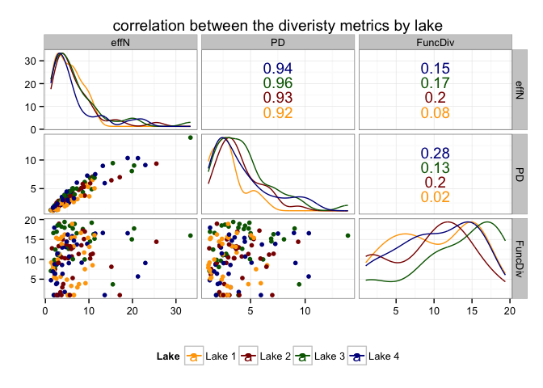

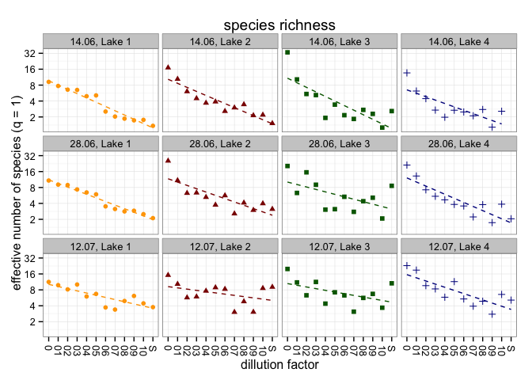

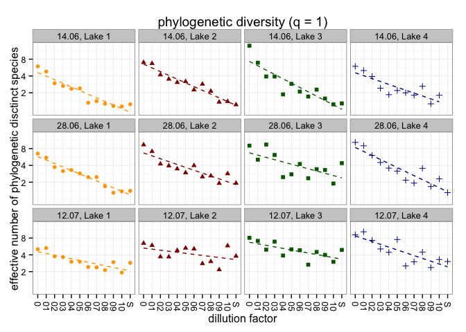

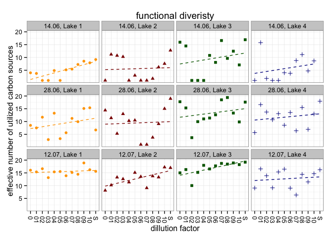

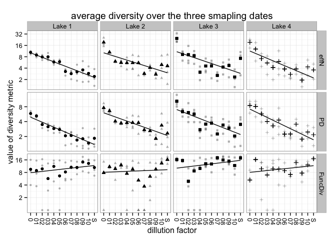

```r
ggsave(plot = G1, "figures/Figure_1.pdf", height = 8, width = 8)
```

```r
avDIV <- select(DIV, -Sampling) %>%
  group_by(BOT, Lake, DIL) %>%
  summarise_each(funs(mean(., na.rm = T)))
```

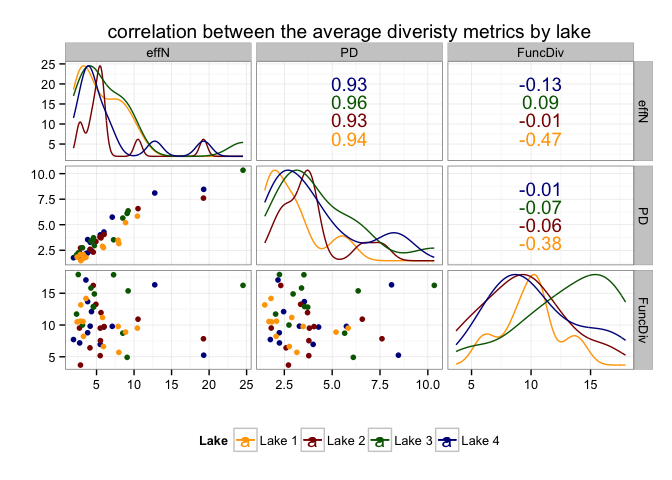

The graph about shows the pearson correlations. We can also look at the r-squares (squared pearson correlations) and the p-values.

```r
# correlation of functional diversity and effective number of species
avDIV %>%
  group_by(Lake) %>%
  do(glance(lm(FuncDiv~effN, data = .)))
```

```
## Source: local data frame [4 x 12]
## Groups: Lake [4]
##
##     Lake    r.squared adj.r.squared    sigma   statistic   p.value    df
##   (fctr)        (dbl)         (dbl)    (dbl)       (dbl)     (dbl) (int)
## 1 Lake 1 0.2251849240    0.14770342 2.233778 2.906305400 0.1190501     2
## 2 Lake 2 0.0001764429   -0.09980591 3.681857 0.001764741 0.9673186     2
## 3 Lake 3 0.0086509003   -0.09048401 4.102021 0.087263914 0.7737274     2
## 4 Lake 4 0.0179242120   -0.08028337 3.880572 0.182513531 0.6782745     2
## Variables not shown: logLik (dbl), AIC (dbl), BIC (dbl), deviance (dbl),
##   df.residual (int)
```

```r
# correlation of functional diveristy and phylogenetic diversity
avDIV %>%
  group_by(Lake) %>%
  do(glance(lm(FuncDiv~PD, data = .)))
```

```
## Source: local data frame [4 x 12]
## Groups: Lake [4]
##
##     Lake    r.squared adj.r.squared    sigma   statistic   p.value    df
##   (fctr)        (dbl)         (dbl)    (dbl)       (dbl)     (dbl) (int)
## 1 Lake 1 0.1440723506    0.05847959 2.347791 1.683230477 0.2236265     2
## 2 Lake 2 0.0037923692   -0.09582839 3.675193 0.038068060 0.8492137     2
## 3 Lake 3 0.0054407076   -0.09401522 4.108658 0.054704709 0.8197888     2
## 4 Lake 4 0.0002196262   -0.09975841 3.915395 0.002196744 0.9635401     2
## Variables not shown: logLik (dbl), AIC (dbl), BIC (dbl), deviance (dbl),
##   df.residual (int)
```

```r
# correlation of effective number of species and phylogenetic diversity
avDIV %>%
  group_by(Lake) %>%
  do(glance(lm(effN~PD, data = .)))
```

```
## Source: local data frame [4 x 12]
## Groups: Lake [4]
##
##     Lake r.squared adj.r.squared    sigma statistic      p.value    df
##   (fctr)     (dbl)         (dbl)    (dbl)     (dbl)        (dbl) (int)
## 1 Lake 1 0.8774130     0.8651543 1.020451  71.57473 7.190865e-06     2
## 2 Lake 2 0.8686066     0.8554672 1.708494  66.10731 1.021456e-05     2
## 3 Lake 3 0.9187231     0.9105954 1.801575 113.03620 9.040442e-07     2
## 4 Lake 4 0.8737350     0.8611085 1.851343  69.19850 8.350667e-06     2
## Variables not shown: logLik (dbl), AIC (dbl), BIC (dbl), deviance (dbl),
##   df.residual (int)
```

Let’s look at some summary statistics of the diveristy metrics.

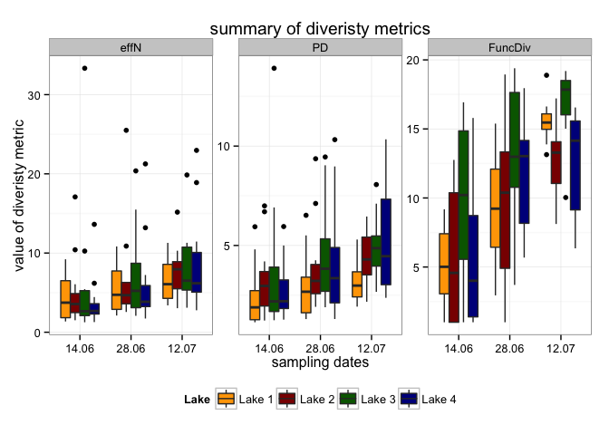

```
## Source: local data frame [9 x 6]
## Groups: DIV_metric [?]
##
##   DIV_metric Sampling      min      max      mean    median
##       (fctr)   (fctr)    (dbl)    (dbl)     (dbl)     (dbl)
## 1       effN    14.06 1.259896 33.33109  4.828799  2.723649
## 2       effN    28.06 1.731353 25.49727  6.342623  4.537528
## 3       effN    12.07 2.772306 22.96350  7.722423  6.432750
## 4         PD    14.06 1.137074 13.91447  3.020397  2.274870
## 5         PD    28.06 1.296256 10.32285  3.889106  3.232310
## 6         PD    12.07 1.922649 10.33915  4.442967  3.935938
## 7    FuncDiv    14.06 1.000000 16.92887  6.447955  5.429557
## 8    FuncDiv    28.06 1.000000 19.39351 10.980427 11.305592
## 9    FuncDiv    12.07 6.352532 19.19320 14.493468 15.166108
```

Now we can correlate each diversity metric to each ecosystem function for each Lake. In order to be able to compare the absolute value of the slopes, we scale all variables to mean = 0 and sd = 1 prior to correlation. Note that the nutrient data is already scaled so we join it after having scaled the other variables.

Also, before we proceed, we exclude dilution level 0 form the data. See the manuscript for a discussion why.

```r
EF <- maxBM %>%
  left_join(Stability) %>%
  left_join(NUT)

BEF <- filter(avDIV, DIL != 0) %>%
  left_join(EF)

head(BEF,2)
```

```
## Source: local data frame [2 x 9]
## Groups: BOT, Lake [2]
##
##     BOT   Lake   DIL      effN       PD   FuncDiv maxCells Stability
##   (int)  (chr) (chr)     (dbl)    (dbl)     (dbl)    (dbl)     (dbl)
## 1     2 Lake 4    01 12.757592 8.104081 16.326130  1525146  11.48845
## 2     3 Lake 4    02  7.092842 5.743966  9.789484  1344364  11.71450
## Variables not shown: DIN (dbl)
```

To see the correlations between the three metrics of EF and the three diversity metrics, we correlate them.

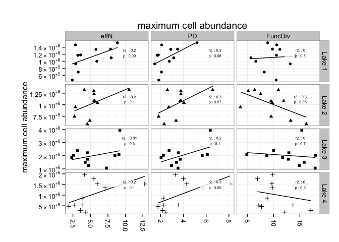

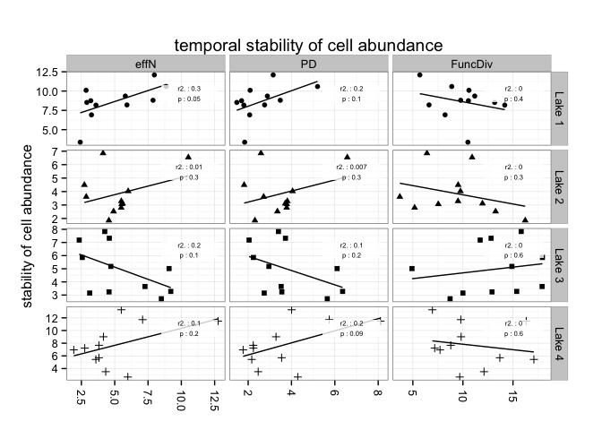

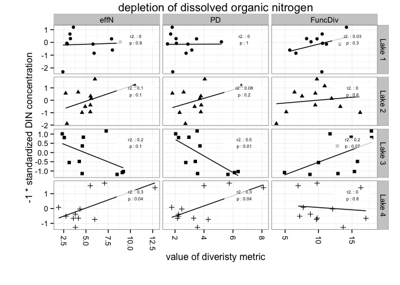

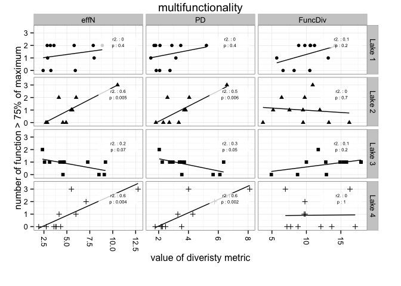

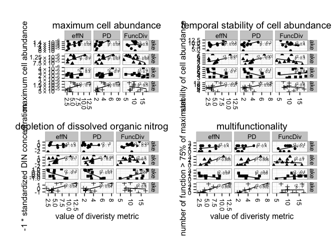

```
## Source: local data frame [48 x 4]
##
##      Lake DIVmetric adj.r.squared     p.value
##     (chr)    (fctr)         (dbl)       (dbl)
## 1  Lake 1      effN   0.203294200 0.092128598
## 2  Lake 1      effN   0.305025390 0.045379803
## 3  Lake 1      effN   0.000000000 0.866481548
## 4  Lake 1        PD   0.231896756 0.075966850
## 5  Lake 1        PD   0.155922488 0.125803290
## 6  Lake 1        PD   0.000000000 0.985582128
## 7  Lake 1   FuncDiv   0.000000000 0.840380241
## 8  Lake 1   FuncDiv   0.000000000 0.408204425
## 9  Lake 1   FuncDiv   0.034817053 0.273389795
## 10 Lake 2      effN   0.156631036 0.125225911
## 11 Lake 2      effN   0.011658319 0.317911709
```

[output cut: 37 more lines]

```
## Source: local data frame [1 x 12]
##
##     r_mean  r_median r_min     r_max    p_mean  p_median       p_min
##      (dbl)     (dbl) (dbl)     (dbl)     (dbl)     (dbl)       (dbl)
## 1 0.162927 0.1365847     0 0.6487464 0.2782142 0.1427732 0.001689648
##       p_max p_0.05 p_0.01 p.cor_0.05 n_cor
##       (dbl)  (int)  (int)      (int) (int)
## 1 0.9855821      9      4          0    48
```

The statics that we present in the plots are linear correlations of the form Ecosystem Function ~ Diversity Metric. As assumption of normality are however not necessarily met, we present also the rank correlations:

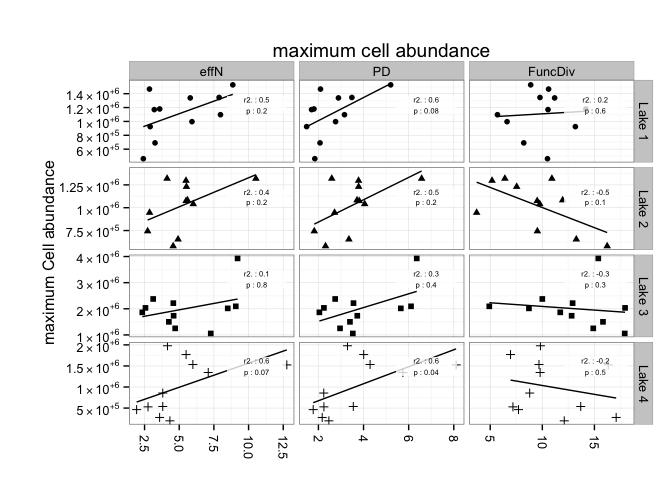

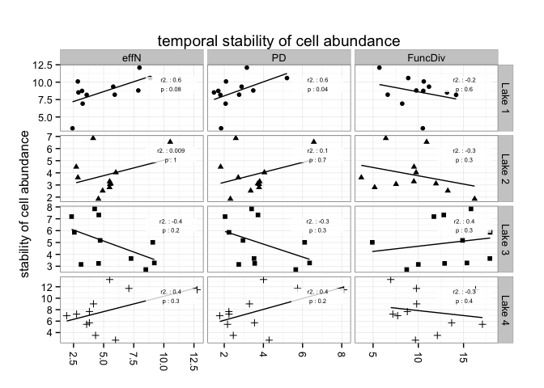

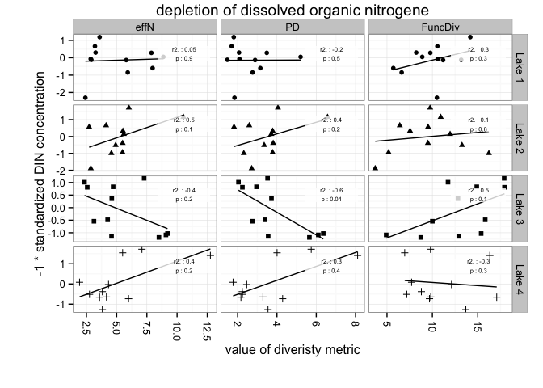

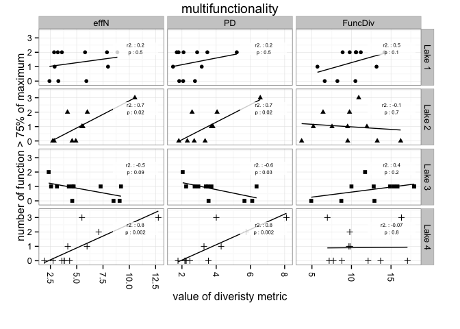

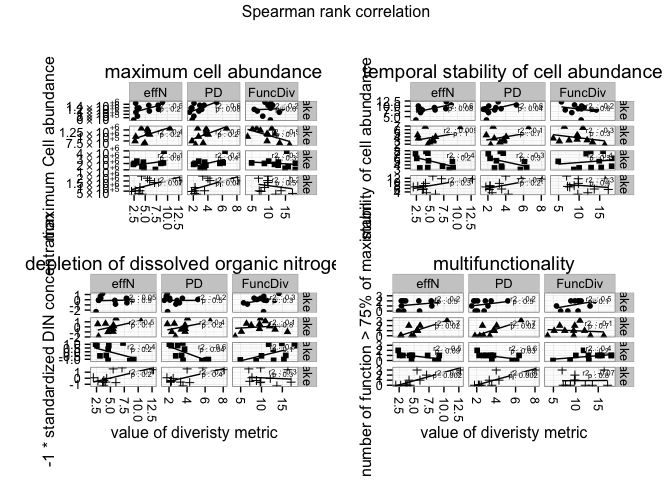

We can compute some summary statistics to see how many relationships are significant and how much variance is explained on average.

```
## Source: local data frame [1 x 12]
##
##      r_mean  r_median       r_min     r_max    p_mean p_median       p_min
##       (dbl)     (dbl)       (dbl)     (dbl)     (dbl)    (dbl)       (dbl)
## 1 0.1554716 0.2423723 0.009090909 0.8273156 0.3157251 0.239185 0.001675212
##       p_max p_0.05 p_0.01 p.cor_0.05 n_cor
##       (dbl)  (int)  (int)      (int) (int)
## 1 0.9891897      8      2          0    48
```